# AIT_T4_BSS_System

```python
import pandas as pd
import numpy as np
import matplotlib.pyplot as plt
import scipy.stats as stats
from datetime import datetime
import seaborn as sns
import folium
import squarify
from folium.plugins import HeatMap
from sklearn.model_selection import train_test_split
from sklearn.metrics import accuracy_score
from sklearn.metrics import confusion_matrix
from sklearn.neighbors import KNeighborsClassifier
```

```python
import warnings
warnings.filterwarnings("ignore") #Ignoring warnings
```

```python
#Importing the data
baltimore_data = pd.read_csv('Crime_Data.csv')
```

```python
baltimore_data_table = pd.DataFrame(baltimore_data)
#baltimore_data_table.info() - checked data types of all columns to get better idea of the data.
```

Data Check and Preprocessing : Remove all the leading and trailing spaces in the data.

```python
baltimore_data.columns = baltimore_data.columns.str.strip()
```

```python
#To find how many duplicate rows are present in the data
print(baltimore_data.duplicated().sum())
#print(baltimore_data[baltimore_data.duplicated()])
```

```
10637
```

```python
# Duplicate rows removed.
data=(baltimore_data.drop_duplicates())
print(data.duplicated().sum())
```

```
0
```

```python
#Checking null/missing values
print('Number of instances = %d\nNumber of attributes = %d' % (data.shape[0], data.shape[1]))
#data.isnull().sum()
```

```
Number of instances = 265892
Number of attributes = 15
```

```python
#Removed all null/missing values.
data.dropna(inplace=True)
#print(data)
print('Number of instances = %d\nNumber of attributes = %d' % (data.shape[0], data.shape[1]))
```

```
Number of instances = 82391
Number of attributes = 15
```

```python
print(sum(data['Total Incidents']))
```

```
82391
```

```
[]
```

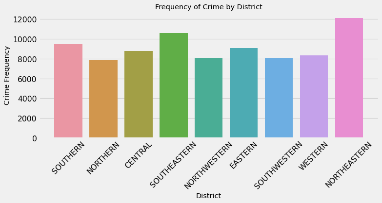

```python
#Graph for frequency of crime by District.

plt.figure(figsize=(10,4), dpi=80)
plt.title('Frequency of Crime by District', fontsize=13)
ax = sns.countplot(x = 'District', data = data)
plt.ylabel("Crime Frequency", fontsize=13)
plt.xlabel('District', fontsize=13)
plt.xticks(rotation = 45)
plt.plot()
```

These are the number of crimes in each District of Baltimore. There are three Districts in Baltimore which has high frequency of crimes. The first District with highest crimes is Northeastern, second is Southeastern and third is Southern side of Baltimore. Central, Eastern and Western part of the Baltimore have less frequency of crimes compare to Northeastern, Southeastern and Southern District. But Northwestern, Southwestern and Northern part has a smaller number of crimes. Hence eastern part of Baltimore has high frequency of crimes as compared to western part of Baltimore.

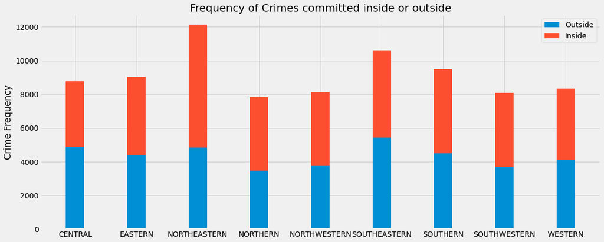

```python
#Frequency of crimes committed inside or outside.

data['Inside/Outside'] = data['Inside/Outside'].replace('I', 'Inside')
data['Inside/Outside'] = data['Inside/Outside'].replace('O', 'Outside')

data1_io = pd.DataFrame(data, columns=['Inside/Outside','Total Incidents','District'])

df_inside = data1_io[data1_io['Inside/Outside'] == "Inside"].groupby(['District'],as_index=False).count()

df_outside = data1_io[data1_io['Inside/Outside'] == "Outside"].groupby(['District'],as_index=False).count()

fig, ax = plt.subplots(figsize=(17,7))
width = 0.3

ax.bar(df_outside.iloc[:,0], df_outside.iloc[:,2], width,  label='Outside')
ax.bar(df_outside.iloc[:,0], df_inside.iloc[:,2], width,  bottom=df_outside.iloc[:,2], label='Inside')

ax.set_ylabel('Crime Frequency')
ax.set_title('Frequency of Crimes committed inside or outside')
ax.legend()

plt.show()
```

Above graph represents number of insode and outside crimes by each district. Districts like central and southeatsern had more outside crimes than inside from 2012 to 2017. Whereas northeastern district had more inside crimes than outside. All other districts had approximately same amount of inside and outside crimes from 2012 to 2017.

```python
#Derived Date,Day,Month,Year,Weekday and Hour from columns CrimeDate and CrimeTime.

data['CrimeTime'] = data['CrimeTime'].str.replace('24:00:00', '00:00:00')
data['Date'] = data['CrimeDate'] + ' ' + data['CrimeTime']

data['Date'] = pd.to_datetime(data['Date'])
data['Day'] = data['Date'].dt.day
data['Month'] = data['Date'].dt.month
data['Year'] = data['Date'].dt.year
data['Weekday'] = data['Date'].dt.weekday + 1
data['Hour'] = data['Date'].dt.hour
```

```
[]
```

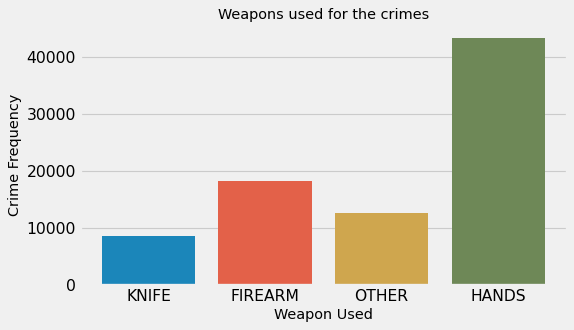

```python
#Graph for Weapons used fro the crimes.

plt.figure(figsize=(7,4), dpi=80)
plt.title('Weapons used for the crimes', fontsize=13)
ax = sns.countplot(x = 'Weapon', data = data)
plt.ylabel("Crime Frequency", fontsize=13)
plt.xlabel('Weapon Used', fontsize=13)
plt.plot()
```

From the above Bar graph, most of the crimes are comitted by Hands. The next highest weapon used for the crime is firearm. Frequency of crimes done by using knife is less compared to other, firearm and hands.

```
[]
```

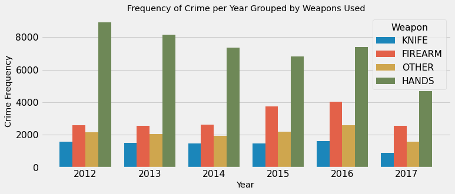

```python
#Graph for Frequency of crimes per year grouped by weapons used.

plt.figure(figsize = (10, 4), dpi = 80)
plt.title("Frequency of Crime per Year Grouped by Weapons Used", fontsize = 13)
ax = sns.countplot(x = "Year", hue = "Weapon", data = data)
plt.ylabel("Crime Frequency", fontsize = 13)
plt.xlabel("Year", fontsize = 13)
plt.plot()
```

```python
Crime_by_Neighbour = data.groupby(['Neighborhood']).sum()
Crime_by_Neighbour.reset_index(inplace = True)

Crime_by_Neighbour.columns = Crime_by_Neighbour.columns.str.replace(' ', '')
max_Crime_neighbour = Crime_by_Neighbour.loc[Crime_by_Neighbour['TotalIncidents'] == max(Crime_by_Neighbour['TotalIncidents'])]
min_Crime_neighbour = Crime_by_Neighbour.loc[Crime_by_Neighbour['TotalIncidents'] == min(Crime_by_Neighbour['TotalIncidents'])]
```

```python
print('The maximum Crime takes place in', max_Crime_neighbour['Neighborhood'].iloc[0],
      'Neighbourhood ' 'and the total no of crimes are',max_Crime_neighbour['TotalIncidents'].iloc[0])
```

```
The maximum Crime takes place in Downtown Neighbourhood and the total no of crimes are 2834
```

```python
print('The minimum Crime and safest Neighbourhood is', min_Crime_neighbour['Neighborhood'].iloc[0],
      'and the total no of crimes are',min_Crime_neighbour['TotalIncidents'].iloc[0])
```

```
The minimum Crime and safest Neighbourhood is Blythewood and the total no of crimes are 1
```

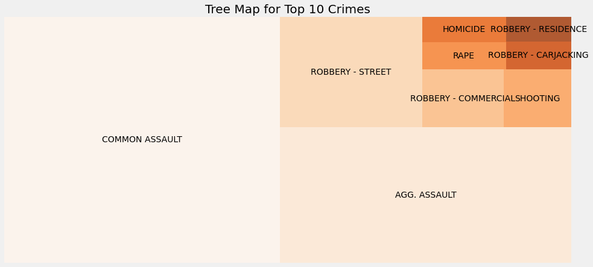

```
COMMON ASSAULT          40054
AGG. ASSAULT            23312
ROBBERY - STREET         9288
ROBBERY - COMMERCIAL     2793
SHOOTING                 2309
RAPE                     1353
HOMICIDE                 1251
ROBBERY - CARJACKING     1072
ROBBERY - RESIDENCE       959
Name: Description, dtype: int64
```

```python
#Tree Map for Top 10 Crimes.

y = data['Description'].value_counts().head(10)

plt.rcParams['figure.figsize'] = (15, 7)
plt.style.use('fivethirtyeight')

color = plt.cm.Oranges(np.linspace(0, 1, 10))
squarify.plot(sizes = y.values, label = y.index, alpha=.8, color = color)
plt.title('Tree Map for Top 10 Crimes', fontsize = 20)

plt.axis('off')
plt.show()

print(y)
```

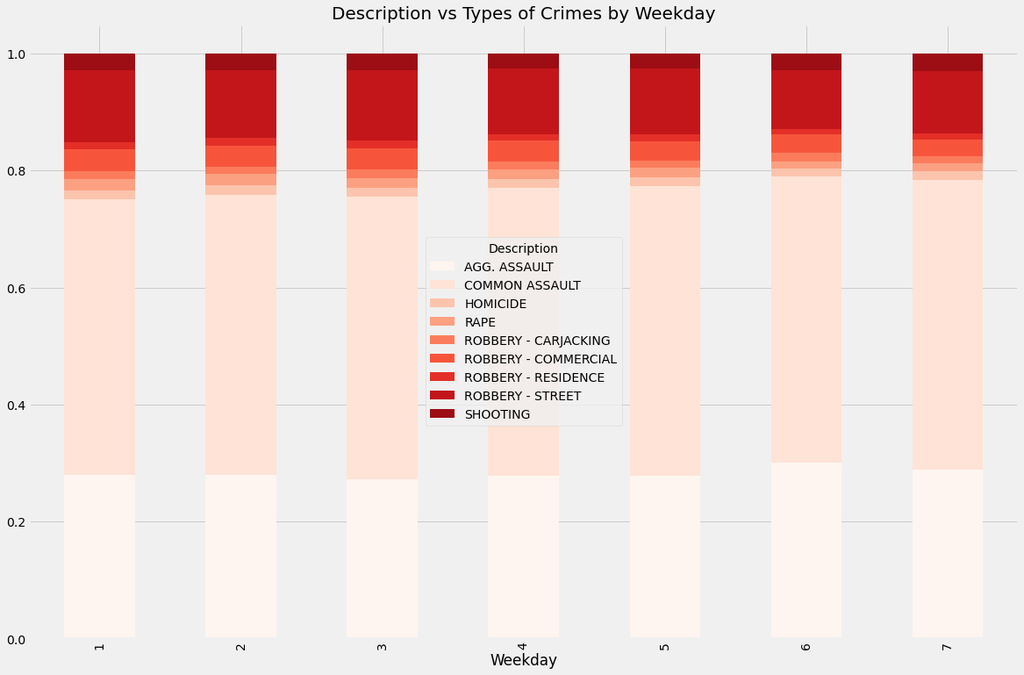

```python
#Graph for description v/s types of crimes by weekday.

data2 = pd.crosstab(data['Weekday'], data['Description'])
color = plt.cm.Reds(np.linspace(0, 1, 10))

data2.div(data2.sum(1).astype(float), axis = 0).plot.bar(stacked = True, color = color, figsize = (18, 12))
plt.title('Description vs Types of Crimes by Weekday', fontweight = 30, fontsize = 20)

plt.xticks(rotation = 90)
plt.show()
```

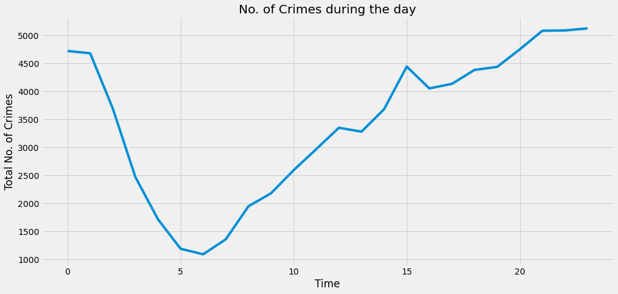

```python
#Graph for number of crimes during the Day.

Most_crime_happen_at = data.groupby(['Hour']).sum()

Most_crime_happen_at.reset_index(inplace = True)

plt.plot(Most_crime_happen_at['Hour'],Most_crime_happen_at['Total Incidents'])
plt.xlabel('Time')
plt.ylabel('Total No. of Crimes')
plt.title('No. of Crimes during the day')
plt.show()
```

The graph shows number of crimes during the day. The highest number of crimes occurs around mid-night. From 12 AM to morning 5 AM there is a massive drop in the crime. From 5 AM again there is increase in the crime till evening 8 PM but the peak time is after 8 PM to mid-night.

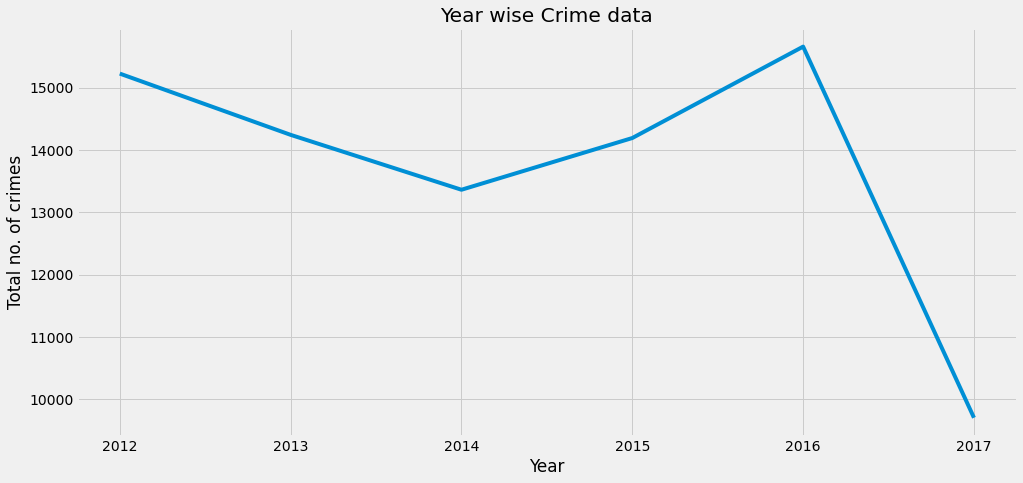

```python
#Graph for year wise crime data.

Year_wise_data = data.groupby(['Year']).sum()

Year_wise_data.reset_index(inplace = True)

Year_wise_data.drop(['Hour'], inplace = True, axis = 1)

x = Year_wise_data['Year']
values = [2012,2013,2014,2015,2016,2017]
plt.plot(Year_wise_data['Year'],Year_wise_data['Total Incidents'])
plt.title('Year wise Crime data')
plt.xlabel('Year')
plt.xticks(x,values)
plt.ylabel('Total no. of crimes')
plt.show()
```

In 2012, there were high crimes in Baltimore city. In 2013 and 2014, the crimes were reduced but for next two years (2015 and 2016) again there was slight increase in number of crimes. But after 2016, there was a significant drop in crime rate.

```
[]
```

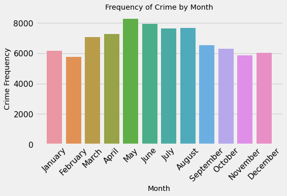

```python
#Graph for frequency of crime by month.

plt.figure(figsize=(7,4), dpi=80)

plt.title('Frequency of Crime by Month', fontsize=13)
ax = sns.countplot(x = 'Month', data = data)
plt.ylabel("Crime Frequency", fontsize=13)
plt.xlabel('Month', fontsize=13)
plt.xticks(rotation = 45)
labels = ['January', 'February', 'March', 'April', 'May', 'June', 'July', 'August', 'September', 'October', 'November', 'December']
ax.set_xticklabels(labels)
plt.plot()
```

The above graph shows frequency of crimes by month. We can see that the highest frequency of crimes occurs in the months of May, June, July and August. We can suspect that, As May to August is a summer time, most people are outside due to good wheather and hences during this time frequency of crime is high whereas during winter period (November to February) crime frequency is low as due to winter people prefer to stay inside and which is the main reason forlesser crimes during this period.

```
[]
```

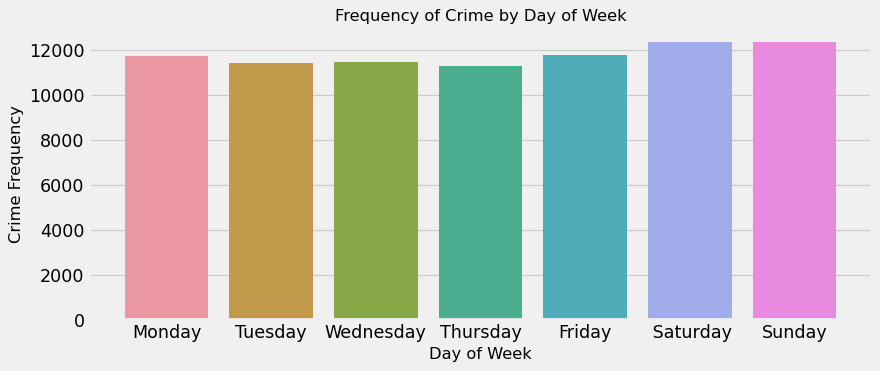

```python
#Graph for frequency of crime by day of week.

plt.figure(figsize=(10,4), dpi=90)

plt.title('Frequency of Crime by Day of Week', fontsize=13)
ax = sns.countplot(x = 'Weekday', data = data)
plt.ylabel("Crime Frequency", fontsize=13)
plt.xlabel('Day of Week', fontsize=13)
labels = ['Monday', 'Tuesday', 'Wednesday', 'Thursday', 'Friday',' Saturday', 'Sunday']
ax.set_xticklabels(labels)
plt.plot()
```

From the above bar graph , we can see that there are more number of crimes on weekends compared to weekdays.

```python
data['Latitude'].median()
data['Longitude'].median()
```

```
-76.6144
```

```python
def generateBaseMap(default_location = [39.30364, -76.6139599], default_zoom_start = 12):
    base_map = folium.Map(location = default_location, control_scale = True, zoom_start = default_zoom_start)
    return base_map

base_map = generateBaseMap()
data_murder = data[data['Description'] == 'HOMICIDE']

HeatMap(
        data = data_murder[['Latitude', 'Longitude']].groupby(
            ['Latitude', 'Longitude']).sum().reset_index().values.tolist(),
        radius = 8,
        max_zoom = 13).add_to(base_map)
base_map
```

Make this Notebook Trusted to load map: File -> Trust Notebook

[interactive chart not shown]

From the above heat map we can determine that, the green color shows the area where the frequency of the crime is high. Hence using this map we can easily analyse that which area is safe and which area is not safe in Baltimore.

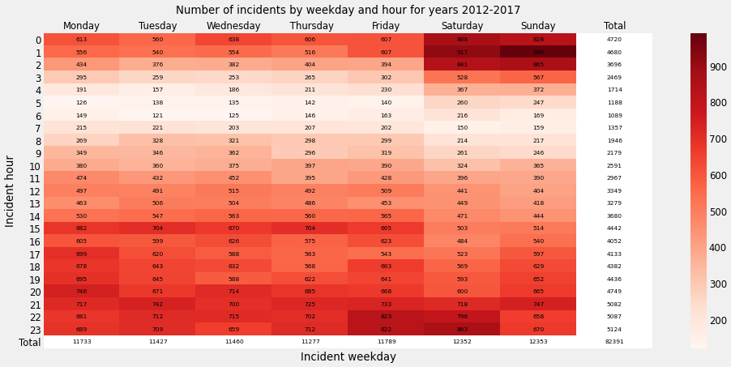

```python
from matplotlib.collections import QuadMesh
from matplotlib.text import Text
import numpy as np

#Manipulating data to feed pivot table to then feed to seaborn heatmap
incidents_wh = data.groupby(['Weekday', 'Hour'])['Total Incidents'].sum()
incidents_wh = incidents_wh.reset_index(level=[0,1]) # to go from mutlindex to singleidnex
pivoted_table = incidents_wh.pivot(index='Hour', columns='Weekday', values='Total Incidents')
pivoted_table.fillna(0, inplace=True)

#Select max value from the data
max_value = pivoted_table.max().max()

#Create sum for rows and columns
pivoted_table.loc['Total'] = pivoted_table.sum()
pivoted_table = pd.concat([pivoted_table,pd.DataFrame(pivoted_table.sum(axis=1),columns=['Total'])],axis=1)

#Generate heatmap
plt.figure(figsize=(18, 8), dpi=60)
ax = sns.heatmap(pivoted_table, cmap='Reds', annot=True, fmt='g', annot_kws={'size': 9}, vmax=max_value)


#Set white color to total column and row
# find your QuadMesh object and get array of colors
quadmesh = ax.findobj(QuadMesh)[0]
facecolors = quadmesh.get_facecolors()

# make colors of the last column white
column_number = pivoted_table.shape[1]
cells_number = pivoted_table.shape[0]*pivoted_table.shape[1]
last_row = pivoted_table.shape[1]*(pivoted_table.shape[0]-1)

facecolors[np.arange(column_number-1,cells_number,column_number)] = np.array([1,1,1,1]) #change column total to white
facecolors[np.arange(last_row, cells_number,1)] = np.array([1,1,1,1]) #change row total to white

# set modified colors
quadmesh.set_facecolors = facecolors

# set color of all text to black
for i in ax.findobj(Text):
    i.set_color('black')

#Labels
labels = ['Monday', 'Tuesday', 'Wednesday',' Thursday', 'Friday', 'Saturday', 'Sunday', 'Total']
ax.set_xticklabels(labels)
ax.xaxis.tick_top()
plt.yticks(rotation=0)
plt.title('Number of incidents by weekday and hour for years 2012-2017', fontsize=16, y=1.05)
plt.xlabel('Incident weekday', fontsize=16)
plt.ylabel('Incident hour', fontsize=16);
```

Classification:

```python
data3 = pd.DataFrame(data, columns=('Weekday','Weapon','Inside/Outside','Longitude','Post','Latitude','Description'))

KNN_data = data3.rename(columns={"Inside/Outside": "IO"})
KNN_data.head()
```

|  | Weekday | Weapon | IO | Longitude | Post | Latitude | Description |
| --- | --- | --- | --- | --- | --- | --- | --- |
| 0 | 6 | KNIFE | Inside | -76.60541 | 913.0 | 39.22951 | ROBBERY - RESIDENCE |
| 2 | 6 | FIREARM | Outside | -76.60697 | 524.0 | 39.34768 | SHOOTING |
| 3 | 6 | OTHER | Inside | -76.64526 | 934.0 | 39.28315 | AGG. ASSAULT |
| 4 | 6 | HANDS | Outside | -76.61365 | 113.0 | 39.28756 | COMMON ASSAULT |
| 6 | 6 | FIREARM | Outside | -76.56827 | 232.0 | 39.28202 | HOMICIDE |

KNN Classification

```python
#Convert Description,IO and Weapon to categorical variables.

KNN_data["Description"] = pd.factorize(KNN_data.Description)[0]
KNN_data["IO"] = pd.factorize(KNN_data.IO)[0]
KNN_data["Weapon"] = pd.factorize(KNN_data.Weapon)[0]

X = np.array(KNN_data.iloc[:,0:6])
y = np.array(KNN_data['Description'])

# split the data into the train and test sets
X_train, X_test, y_train, y_test = train_test_split(X, y, test_size=0.20)

knn = KNeighborsClassifier(n_neighbors=100)
knn.fit(X_train, y_train)
pred = knn.predict(X_test)

print ('\nModel accuracy score: ', accuracy_score(y_test, pred))

print('\nConfusion Matrix\n', confusion_matrix(y_test, pred))
```

```
Model accuracy score:  0.6877237696462164

Confusion Matrix
 [[   0    0  157   26    0    0   14    0    0]
 [   0    0  350    0    0    1   97    0    0]
 [   0    0 2547 1740    0    5  379    0    0]
 [   0    0    0 8023    0    0    0    0    0]
 [   0    0  186   17    0    0   54    0    0]
 [   0    0  417   48    0   14   86    0    0]
 [   0    0  977   91    0    2  749    0    0]
 [   0    0  128    5    0    0   87    0    0]
 [   0    0   90  188    0    0    1    0    0]]
```

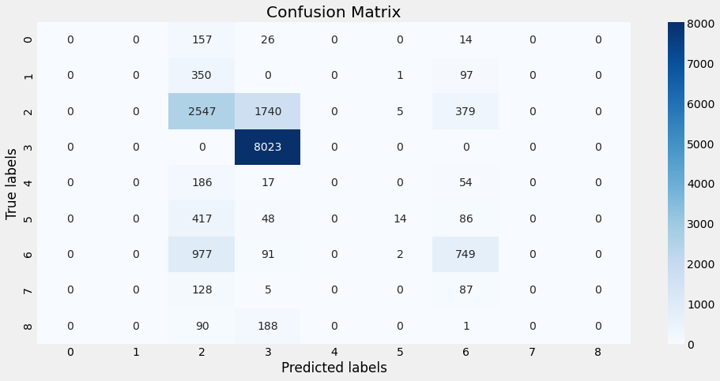

```python
cm = confusion_matrix(y_test,pred)
fig, ax = plt.subplots(figsize=(15, 7))

sns.heatmap(cm, annot=True,fmt='',cmap='Blues')

ax.set_xlabel('Predicted labels');
ax.set_ylabel('True labels');
ax.set_title('Confusion Matrix');
```

```python
#Fitting In RandomForest Ensemble
from sklearn.ensemble import RandomForestClassifier
rfc = RandomForestClassifier(n_estimators=40,min_samples_split=100 )
rfc.fit(X_train, y_train)

#Predicting The Final Results
rfc_pred = rfc.predict(X_test)
print ("Train Accuracy: ", accuracy_score(y_train, rfc.predict(X_train)))
print ("Test Accuracy: ", accuracy_score(y_test, rfc_pred))
```

```
Train Accuracy:  0.7908575069790023
Test Accuracy:  0.776928211663329
```

Accuracy of model using KNN classification was 68%. To improve the accuracy we used more optimized machine learning method i.e. Random Forest Method. In Random Forest Method, tree value (estimators) is 40 and accuracy of model improved to 77%.